# Week 5 Decision Tree

## Motivation

- Basic idea: recursively partitioning the input space in training step and traverse the tree with test data point to predict
- Classification problem setup:
  - training dataset
  - testing dataset
  - validation dataset
  - Model
- Transparent method: a tree-like structure that emulate human’s decision making flow
  - Can be converted into decision rules
  - Similarity to association rules

## Decision Tree Structure

- Node: attribute splitting
  - root, leaf, internal nodes
- Branch: attribute condition testing
  - Binary or more

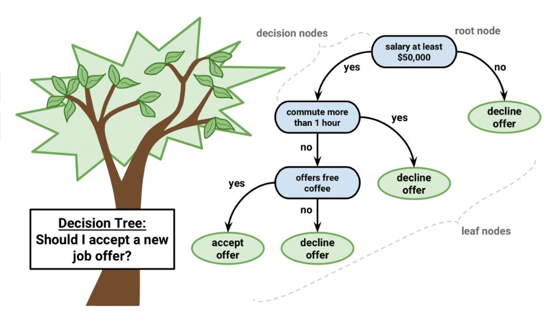

## Framework of Supervised Learning

- Induction: model building from training data
  - Specific -> General
- Deduction: model prediction on testing data
  - General -> Specific
- Eager vs. lazy learning: presence of induction step

## Major Application of Decision Tree Induction Algorithm

- Improve business decision making and support in a lot of industries: finance, banking, insurance, healthcare, etc.
- Enhance customer service levels
- Knowledge management platform to facilitate easier knowledge findability

## Algorithm Summary (Hunt’s Algorithm)

- Goal: improve dataset purity by *recursively* splitting with attributes
- Check if a dataset \(D_t\) is pure: if yes, then label it as a leaf node; if not, continue
- Choose the attribute and (in the case of numerical attributes) split points that maximize information gain to split the dataset
- Keep splitting until one of stop conditions is met
  - when all the data points belong to the same class
  - when all the records have the same attribute values
  - Early termination: set by model parameters (e.g. minsplit, minbucket, maxdepth) that control pruning
- Other algorithm: ID3, C4.5, C5.0, CART

## Attributes for Decision Tree

- Categorical attributes
  - Binary attributes: Classification And Regression Tree (CART) constructs binary trees
  - Multinomial attributes: grouping to reduce number of child nodes
- Numerical attributes
  - Often discretized into binary attribute
  - Pick a splitting point (cutoff) on the attribute

## Data Impurity Measure: Entropy

- Entropy: property of a dataset \(D\) and the classification \(C\)
  - \(Entropy(D, C) = -\sum_i^nP_i\log_2P_i\)
- Entropy curve for binary classification

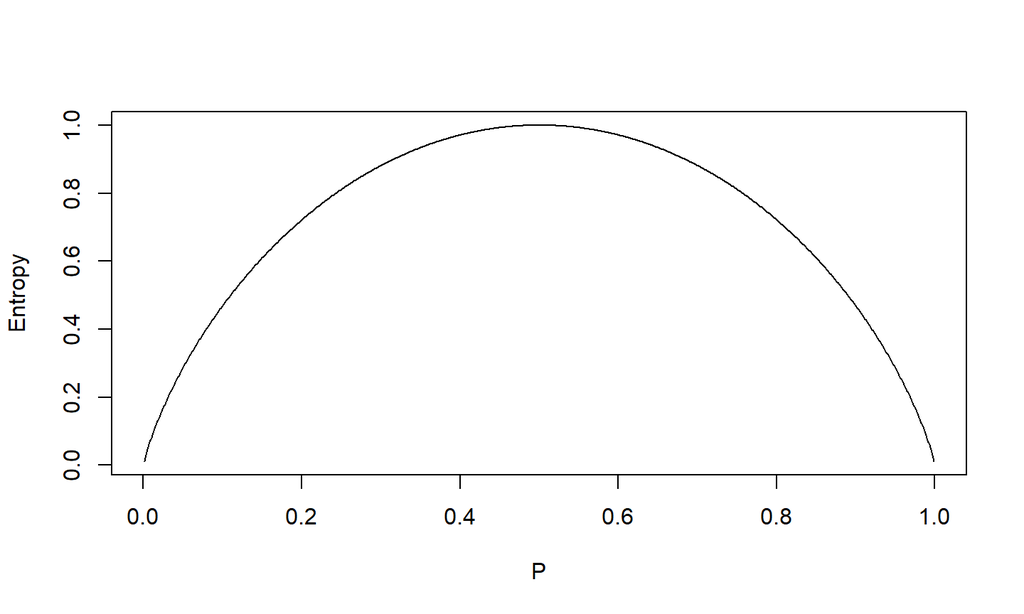

## Other Impurity Measure: Gini Index

- Common characteristics of data impurity metric
  - Correlate with data purity with regards to targt class label
  - If data is more pure/homogeneous, metric has a lower value; if data is less pure/heterogeneous, metric has a higher value
- Gini index
  - \(GINI(D, C) = 1 - \sum_i^{|Classes|}{P_i^2}\)
  - Special cases

## Information Gain

- Information gain: property of entropy (\(D\), \(C\)) and attribute (\(A\)) \[ IG(A, D, C) = Entropy(D_{Before Splitting}) - Entropy(D_{After Splitting}) \] \[ Entropy(S_{After Splitting}) = \sum_j^m{\frac{N_j}{N}} Entropy(S_j) \]
  - Adopted in ID3 algorithm
- Gain ratio: Adjust information gain to control for number of groups after splitting \[ GR(Attr) = \frac{IG(Attr)}{-\sum_j^m{\frac{n_j}{n}}\log_2{\frac{n_j}{n}}} \]
  - Adopted in C4.5 algorithm

## Occam’s Razor

- Smaller models are preferred given similar training accuracy
- The complexity of a decision tree is defined as the number of splits in the tree
- Pruning: reduce the size of the decision tree
  - Prepruning: halt tree construction early; requires setting threshold to stop attributes splitting
  - Postpruning: remove branches from a “fully grown” tree

## Overfitting

- Training accuracy vs.testing accuracy

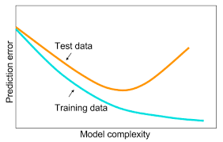

## Model Parameters

- Set by rpart.control() function in *rpart* package.
  - rpart.control(minsplit = 20, minbucket = round(minsplit/3), cp = 0.01, maxdepth = 30, …)
- Minbucket: the minimum number of observations in any terminal node.
- Minsplit: the minimum number of observations that must exist in a node in order for a split to be attempted.
- Maxdepth: maximum depth of any node of the final tree, with the root node counted as depth 0.
- Complexity parameter (cp = ): the improvement of model fit in order to create a new branch
  - When cp is set to a lower value, more complex the model can be; therefore increase cp to **prune**
  - Question: how to set cp for a fully grown tree
- In order to avoid overfitting, we should increase minbucket, minsplit, or cp; or decrease maxdepth

## Properties of the Algorithm

- Greedy algorithm: top-down, recursive partitioning strategy
- Rectlinear decision boundary (rectangles or hyper-rectangles)
- Data fragmentation
- Slow training process to build model, fast to predict
- Robust to outliers
- Non-parametric model: no underlying assumptions for the model
- Output models either as a tree or as a set of rules (similar to association rules)

## Demo Dataset

churn dataset from C50 package

```r
# install.packages("C50")
library(C50)
data(churn)
churn <- rbind(churnTrain, churnTest)
str(churnTrain)
```

```
## 'data.frame':    3333 obs. of  20 variables:
##  $ state                        : Factor w/ 51 levels "AK","AL","AR",..: 17 36 32 36 37 2 20 25 19 50 ...
##  $ account_length               : int  128 107 137 84 75 118 121 147 117 141 ...
##  $ area_code                    : Factor w/ 3 levels "area_code_408",..: 2 2 2 1 2 3 3 2 1 2 ...
##  $ international_plan           : Factor w/ 2 levels "no","yes": 1 1 1 2 2 2 1 2 1 2 ...
##  $ voice_mail_plan              : Factor w/ 2 levels "no","yes": 2 2 1 1 1 1 2 1 1 2 ...
##  $ number_vmail_messages        : int  25 26 0 0 0 0 24 0 0 37 ...
##  $ total_day_minutes            : num  265 162 243 299 167 ...
##  $ total_day_calls              : int  110 123 114 71 113 98 88 79 97 84 ...
##  $ total_day_charge             : num  45.1 27.5 41.4 50.9 28.3 ...
##  $ total_eve_minutes            : num  197.4 195.5 121.2 61.9 148.3 ...
##  $ total_eve_calls              : int  99 103 110 88 122 101 108 94 80 111 ...
##  $ total_eve_charge             : num  16.78 16.62 10.3 5.26 12.61 ...
##  $ total_night_minutes          : num  245 254 163 197 187 ...
##  $ total_night_calls            : int  91 103 104 89 121 118 118 96 90 97 ...
##  $ total_night_charge           : num  11.01 11.45 7.32 8.86 8.41 ...
##  $ total_intl_minutes           : num  10 13.7 12.2 6.6 10.1 6.3 7.5 7.1 8.7 11.2 ...
##  $ total_intl_calls             : int  3 3 5 7 3 6 7 6 4 5 ...
##  $ total_intl_charge            : num  2.7 3.7 3.29 1.78 2.73 1.7 2.03 1.92 2.35 3.02 ...
##  $ number_customer_service_calls: int  1 1 0 2 3 0 3 0 1 0 ...
##  $ churn                        : Factor w/ 2 levels "yes","no": 2 2 2 2 2 2 2 2 2 2 ...
```

```r
str(churnTest)
```

```
## 'data.frame':    1667 obs. of  20 variables:
##  $ state                        : Factor w/ 51 levels "AK","AL","AR",..: 12 27 36 33 41 13 29 19 25 44 ...
##  $ account_length               : int  101 137 103 99 108 117 63 94 138 128 ...
##  $ area_code                    : Factor w/ 3 levels "area_code_408",..: 3 3 1 2 2 2 2 1 3 2 ...
##  $ international_plan           : Factor w/ 2 levels "no","yes": 1 1 1 1 1 1 1 1 1 1 ...
##  $ voice_mail_plan              : Factor w/ 2 levels "no","yes": 1 1 2 1 1 1 2 1 1 2 ...
##  $ number_vmail_messages        : int  0 0 29 0 0 0 32 0 0 43 ...
##  $ total_day_minutes            : num  70.9 223.6 294.7 216.8 197.4 ...
##  $ total_day_calls              : int  123 86 95 123 78 85 124 97 117 100 ...
##  $ total_day_charge             : num  12.1 38 50.1 36.9 33.6 ...
##  $ total_eve_minutes            : num  212 245 237 126 124 ...
##  $ total_eve_calls              : int  73 139 105 88 101 68 125 112 46 89 ...
##  $ total_eve_charge             : num  18 20.8 20.2 10.7 10.5 ...
##  $ total_night_minutes          : num  236 94.2 300.3 220.6 204.5 ...
##  $ total_night_calls            : int  73 81 127 82 107 90 120 106 71 92 ...
##  $ total_night_charge           : num  10.62 4.24 13.51 9.93 9.2 ...
##  $ total_intl_minutes           : num  10.6 9.5 13.7 15.7 7.7 6.9 12.9 11.1 9.9 11.9 ...
##  $ total_intl_calls             : int  3 7 6 2 4 5 3 6 4 1 ...
##  $ total_intl_charge            : num  2.86 2.57 3.7 4.24 2.08 1.86 3.48 3 2.67 3.21 ...
##  $ number_customer_service_calls: int  3 0 1 1 2 1 1 0 2 0 ...
##  $ churn                        : Factor w/ 2 levels "yes","no": 2 2 2 2 2 2 2 2 2 2 ...
```

```r
# add a code to combine two datasets and mark which one is which
str(churn)
```

```
## 'data.frame':    5000 obs. of  20 variables:
##  $ state                        : Factor w/ 51 levels "AK","AL","AR",..: 17 36 32 36 37 2 20 25 19 50 ...
##  $ account_length               : int  128 107 137 84 75 118 121 147 117 141 ...
##  $ area_code                    : Factor w/ 3 levels "area_code_408",..: 2 2 2 1 2 3 3 2 1 2 ...
##  $ international_plan           : Factor w/ 2 levels "no","yes": 1 1 1 2 2 2 1 2 1 2 ...
##  $ voice_mail_plan              : Factor w/ 2 levels "no","yes": 2 2 1 1 1 1 2 1 1 2 ...
##  $ number_vmail_messages        : int  25 26 0 0 0 0 24 0 0 37 ...
##  $ total_day_minutes            : num  265 162 243 299 167 ...
##  $ total_day_calls              : int  110 123 114 71 113 98 88 79 97 84 ...
##  $ total_day_charge             : num  45.1 27.5 41.4 50.9 28.3 ...
##  $ total_eve_minutes            : num  197.4 195.5 121.2 61.9 148.3 ...
##  $ total_eve_calls              : int  99 103 110 88 122 101 108 94 80 111 ...
##  $ total_eve_charge             : num  16.78 16.62 10.3 5.26 12.61 ...
##  $ total_night_minutes          : num  245 254 163 197 187 ...
##  $ total_night_calls            : int  91 103 104 89 121 118 118 96 90 97 ...
##  $ total_night_charge           : num  11.01 11.45 7.32 8.86 8.41 ...
##  $ total_intl_minutes           : num  10 13.7 12.2 6.6 10.1 6.3 7.5 7.1 8.7 11.2 ...
##  $ total_intl_calls             : int  3 3 5 7 3 6 7 6 4 5 ...
##  $ total_intl_charge            : num  2.7 3.7 3.29 1.78 2.73 1.7 2.03 1.92 2.35 3.02 ...
##  $ number_customer_service_calls: int  1 1 0 2 3 0 3 0 1 0 ...
##  $ churn                        : Factor w/ 2 levels "yes","no": 2 2 2 2 2 2 2 2 2 2 ...
```

## Model Training

```r
library(caret)
library(rpart)
dt_model <- train(churn ~ ., data = churnTrain, metric = "Accuracy", method = "rpart")
typeof(dt_model)
```

```
## [1] "list"
```

```r
names(dt_model)
```

```
##  [1] "method"       "modelInfo"    "modelType"    "results"
##  [5] "pred"         "bestTune"     "call"         "dots"
##  [9] "metric"       "control"      "finalModel"   "preProcess"
## [13] "trainingData" "resample"     "resampledCM"  "perfNames"
## [17] "maximize"     "yLimits"      "times"        "levels"
## [21] "terms"        "coefnames"    "contrasts"    "xlevels"
```

## Check Decision Tree Classifiers

```r
print(dt_model)
```

```
## CART
##
## 3333 samples
##   19 predictor
##    2 classes: 'yes', 'no'
##
## No pre-processing
## Resampling: Bootstrapped (25 reps)
## Summary of sample sizes: 3333, 3333, 3333, 3333, 3333, 3333, ...
## Resampling results across tuning parameters:
##
##   cp          Accuracy   Kappa
##   0.07867495  0.8748801  0.2886734
##   0.08488613  0.8680891  0.2067973
##   0.08902692  0.8631883  0.1405265
##
## Accuracy was used to select the optimal model using the largest value.
## The final value used for the model was cp = 0.07867495.
```

## Check Decision Tree Classifier Details

```r
print(dt_model$finalModel)
```

```
## n= 3333
##
## node), split, n, loss, yval, (yprob)
##       * denotes terminal node
##
## 1) root 3333 483 no (0.1449145 0.8550855)
##   2) total_day_minutes>=264.45 211  84 yes (0.6018957 0.3981043)
##     4) voice_mail_planyes< 0.5 158  37 yes (0.7658228 0.2341772) *
##     5) voice_mail_planyes>=0.5 53   6 no (0.1132075 0.8867925) *
##   3) total_day_minutes< 264.45 3122 356 no (0.1140295 0.8859705) *
```

## Model Prediction (1)

```r
dt_predict <- predict(dt_model, newdata = churnTest, na.action = na.omit, type = "prob")
head(dt_predict, 5)
```

```
##         yes        no
## 1 0.1140295 0.8859705
## 2 0.1140295 0.8859705
## 3 0.1132075 0.8867925
## 4 0.1140295 0.8859705
## 5 0.1140295 0.8859705
```

## Model Prediction (2)

```r
dt_predict2 <- predict(dt_model, newdata = churnTest, type = "raw")
head(dt_predict2)
```

```
## [1] no no no no no no
## Levels: yes no
```

## Model Tuning (1)

```r
dt_model_tune <- train(churn ~ ., data = churnTrain, method = "rpart",
                       metric = "Accuracy",
                       tuneLength = 8)
print(dt_model_tune$finalModel)
```

```
## n= 3333
##
## node), split, n, loss, yval, (yprob)
##       * denotes terminal node
##
##   1) root 3333 483 no (0.14491449 0.85508551)
##     2) total_day_minutes>=264.45 211  84 yes (0.60189573 0.39810427)
##       4) voice_mail_planyes< 0.5 158  37 yes (0.76582278 0.23417722)
##         8) total_eve_minutes>=187.75 101   5 yes (0.95049505 0.04950495) *
##         9) total_eve_minutes< 187.75 57  25 no (0.43859649 0.56140351)
##          18) total_day_minutes>=277.7 32  11 yes (0.65625000 0.34375000)
##            36) total_eve_minutes>=144.35 24   4 yes (0.83333333 0.16666667) *
##            37) total_eve_minutes< 144.35 8   1 no (0.12500000 0.87500000) *
##          19) total_day_minutes< 277.7 25   4 no (0.16000000 0.84000000) *
##       5) voice_mail_planyes>=0.5 53   6 no (0.11320755 0.88679245) *
##     3) total_day_minutes< 264.45 3122 356 no (0.11402947 0.88597053)
##       6) number_customer_service_calls>=3.5 251 124 yes (0.50597610 0.49402390)
##        12) total_day_minutes< 160.2 102  13 yes (0.87254902 0.12745098) *
##        13) total_day_minutes>=160.2 149  38 no (0.25503356 0.74496644)
##          26) total_eve_minutes< 141.75 19   5 yes (0.73684211 0.26315789) *
##          27) total_eve_minutes>=141.75 130  24 no (0.18461538 0.81538462)
##            54) total_day_minutes< 175.75 34  14 no (0.41176471 0.58823529)
##             108) total_eve_minutes< 212.15 16   2 yes (0.87500000 0.12500000) *
##             109) total_eve_minutes>=212.15 18   0 no (0.00000000 1.00000000) *
##            55) total_day_minutes>=175.75 96  10 no (0.10416667 0.89583333) *
##       7) number_customer_service_calls< 3.5 2871 229 no (0.07976315 0.92023685)
##        14) international_planyes>=0.5 267 101 no (0.37827715 0.62172285)
##          28) total_intl_calls< 2.5 51   0 yes (1.00000000 0.00000000) *
##          29) total_intl_calls>=2.5 216  50 no (0.23148148 0.76851852)
##            58) total_intl_minutes>=13.1 43   0 yes (1.00000000 0.00000000) *
##            59) total_intl_minutes< 13.1 173   7 no (0.04046243 0.95953757) *
##        15) international_planyes< 0.5 2604 128 no (0.04915515 0.95084485)
##          30) total_day_minutes>=223.25 383  68 no (0.17754569 0.82245431)
##            60) total_eve_minutes>=259.8 51  17 yes (0.66666667 0.33333333)
##             120) voice_mail_planyes< 0.5 40   6 yes (0.85000000 0.15000000) *
##             121) voice_mail_planyes>=0.5 11   0 no (0.00000000 1.00000000) *
##            61) total_eve_minutes< 259.8 332  34 no (0.10240964 0.89759036) *
##          31) total_day_minutes< 223.25 2221  60 no (0.02701486 0.97298514) *
```

## Model Tuning (2)

```r
dt_model_tune2 <- train(churn ~ ., data = churnTrain, method = "rpart",
                        tuneGrid = expand.grid(cp = seq(0, 0.1, 0.01)))
print(dt_model_tune2$finalModel)
```

```
## n= 3333
##
## node), split, n, loss, yval, (yprob)
##       * denotes terminal node
##
##   1) root 3333 483 no (0.14491449 0.85508551)
##     2) total_day_minutes>=264.45 211  84 yes (0.60189573 0.39810427)
##       4) voice_mail_planyes< 0.5 158  37 yes (0.76582278 0.23417722)
##         8) total_eve_minutes>=187.75 101   5 yes (0.95049505 0.04950495) *
##         9) total_eve_minutes< 187.75 57  25 no (0.43859649 0.56140351)
##          18) total_day_minutes>=277.7 32  11 yes (0.65625000 0.34375000)
##            36) total_eve_minutes>=144.35 24   4 yes (0.83333333 0.16666667) *
##            37) total_eve_minutes< 144.35 8   1 no (0.12500000 0.87500000) *
##          19) total_day_minutes< 277.7 25   4 no (0.16000000 0.84000000) *
##       5) voice_mail_planyes>=0.5 53   6 no (0.11320755 0.88679245) *
##     3) total_day_minutes< 264.45 3122 356 no (0.11402947 0.88597053)
##       6) number_customer_service_calls>=3.5 251 124 yes (0.50597610 0.49402390)
##        12) total_day_minutes< 160.2 102  13 yes (0.87254902 0.12745098) *
##        13) total_day_minutes>=160.2 149  38 no (0.25503356 0.74496644)
##          26) total_eve_minutes< 141.75 19   5 yes (0.73684211 0.26315789) *
##          27) total_eve_minutes>=141.75 130  24 no (0.18461538 0.81538462)
##            54) total_day_minutes< 175.75 34  14 no (0.41176471 0.58823529)
##             108) total_eve_minutes< 212.15 16   2 yes (0.87500000 0.12500000) *
##             109) total_eve_minutes>=212.15 18   0 no (0.00000000 1.00000000) *
##            55) total_day_minutes>=175.75 96  10 no (0.10416667 0.89583333) *
##       7) number_customer_service_calls< 3.5 2871 229 no (0.07976315 0.92023685)
##        14) international_planyes>=0.5 267 101 no (0.37827715 0.62172285)
##          28) total_intl_calls< 2.5 51   0 yes (1.00000000 0.00000000) *
##          29) total_intl_calls>=2.5 216  50 no (0.23148148 0.76851852)
##            58) total_intl_minutes>=13.1 43   0 yes (1.00000000 0.00000000) *
##            59) total_intl_minutes< 13.1 173   7 no (0.04046243 0.95953757) *
##        15) international_planyes< 0.5 2604 128 no (0.04915515 0.95084485)
##          30) total_day_minutes>=223.25 383  68 no (0.17754569 0.82245431)
##            60) total_eve_minutes>=259.8 51  17 yes (0.66666667 0.33333333)
##             120) voice_mail_planyes< 0.5 40   6 yes (0.85000000 0.15000000) *
##             121) voice_mail_planyes>=0.5 11   0 no (0.00000000 1.00000000) *
##            61) total_eve_minutes< 259.8 332  34 no (0.10240964 0.89759036) *
##          31) total_day_minutes< 223.25 2221  60 no (0.02701486 0.97298514) *
```

## Model Pre-Pruning

```r
dt_model_preprune <- train(churn ~ ., data = churnTrain, method = "rpart",
                       metric = "Accuracy",
                       tuneLength = 8,
                       control = rpart.control(minsplit = 50, minbucket = 20, maxdepth = 5))
print(dt_model_preprune$finalModel)
```

```
## n= 3333
##
## node), split, n, loss, yval, (yprob)
##       * denotes terminal node
##
##  1) root 3333 483 no (0.14491449 0.85508551)
##    2) total_day_minutes>=264.45 211  84 yes (0.60189573 0.39810427)
##      4) voice_mail_planyes< 0.5 158  37 yes (0.76582278 0.23417722)
##        8) total_eve_minutes>=187.75 101   5 yes (0.95049505 0.04950495) *
##        9) total_eve_minutes< 187.75 57  25 no (0.43859649 0.56140351)
##         18) total_day_minutes>=277.7 32  11 yes (0.65625000 0.34375000) *
##         19) total_day_minutes< 277.7 25   4 no (0.16000000 0.84000000) *
##      5) voice_mail_planyes>=0.5 53   6 no (0.11320755 0.88679245) *
##    3) total_day_minutes< 264.45 3122 356 no (0.11402947 0.88597053)
##      6) number_customer_service_calls>=3.5 251 124 yes (0.50597610 0.49402390)
##       12) total_day_minutes< 160.2 102  13 yes (0.87254902 0.12745098) *
##       13) total_day_minutes>=160.2 149  38 no (0.25503356 0.74496644)
##         26) total_eve_minutes< 155.5 29  11 yes (0.62068966 0.37931034) *
##         27) total_eve_minutes>=155.5 120  20 no (0.16666667 0.83333333) *
##      7) number_customer_service_calls< 3.5 2871 229 no (0.07976315 0.92023685)
##       14) international_planyes>=0.5 267 101 no (0.37827715 0.62172285)
##         28) total_intl_calls< 2.5 51   0 yes (1.00000000 0.00000000) *
##         29) total_intl_calls>=2.5 216  50 no (0.23148148 0.76851852)
##           58) total_intl_minutes>=13.1 43   0 yes (1.00000000 0.00000000) *
##           59) total_intl_minutes< 13.1 173   7 no (0.04046243 0.95953757) *
##       15) international_planyes< 0.5 2604 128 no (0.04915515 0.95084485)
##         30) total_day_minutes>=223.25 383  68 no (0.17754569 0.82245431)
##           60) total_eve_minutes>=259.8 51  17 yes (0.66666667 0.33333333) *
##           61) total_eve_minutes< 259.8 332  34 no (0.10240964 0.89759036) *
##         31) total_day_minutes< 223.25 2221  60 no (0.02701486 0.97298514) *
```

## Model Post-pruning

```r
dt_model_postprune <- prune(dt_model$finalModel, cp = 0.2)
print(dt_model_postprune)
```

```
## n= 3333
##
## node), split, n, loss, yval, (yprob)
##       * denotes terminal node
##
## 1) root 3333 483 no (0.1449145 0.8550855) *
```

## Check Decision Tree Classifier (1)

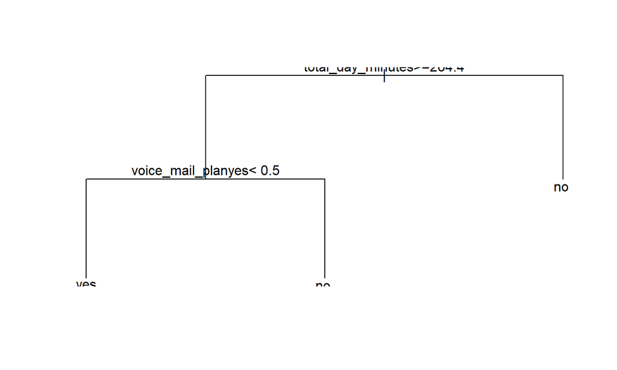

```r
plot(dt_model$finalModel)
text(dt_model$finalModel)
```

```r
summary(dt_model$finalModel)
```

[output not shown]

[output cut: 14213 more lines]

## Check Decision Tree Classifier (2)

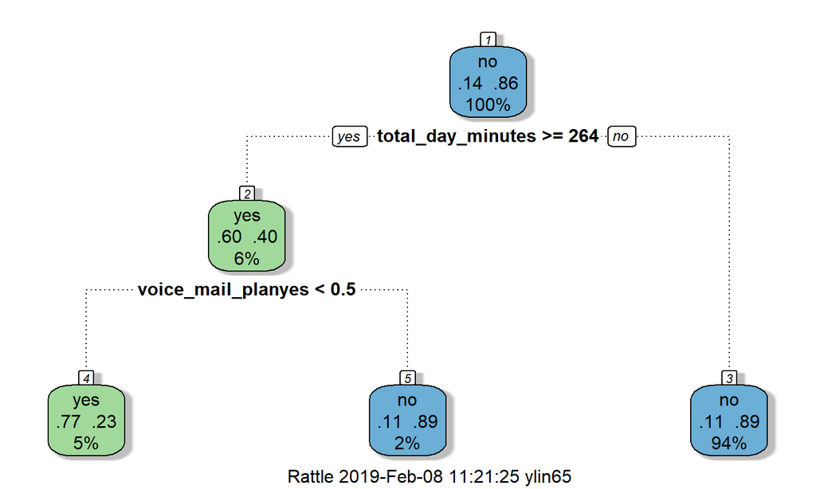

```r
library(rattle)
fancyRpartPlot(dt_model$finalModel)
```

## Check Decision Tree Classifier (3)

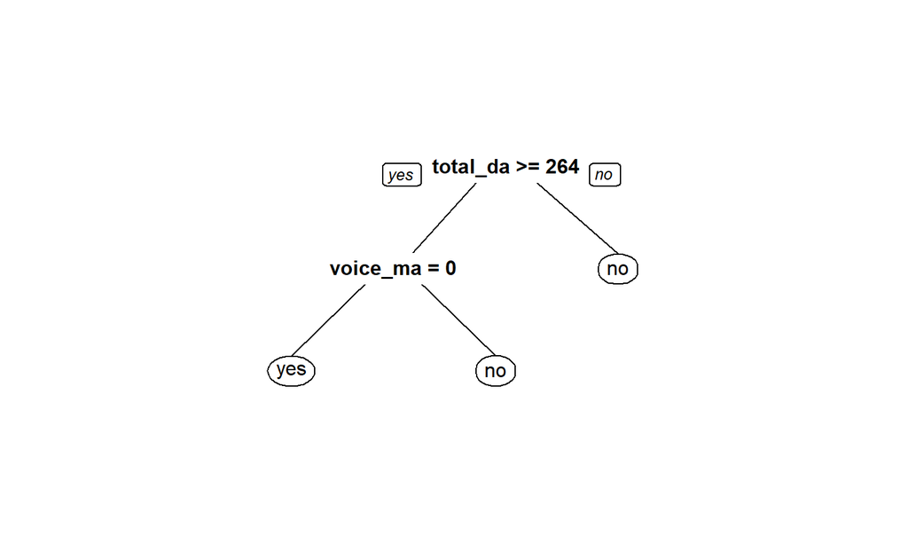

```r
library(rpart.plot)
prp(dt_model$finalModel)
```

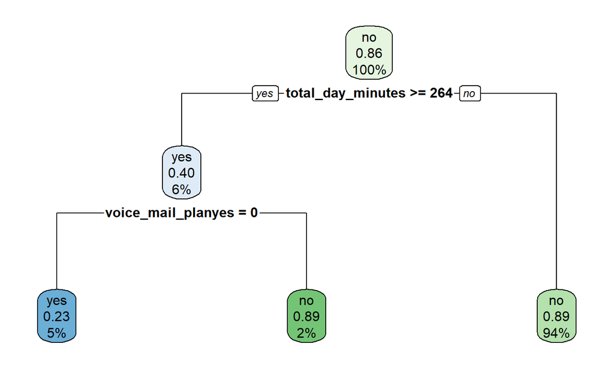

```r
rpart.plot(dt_model$finalModel)
```